# Assignment 6 - Solution - Statistics II, Hertie School

4. Now fit an RD model of your choice and report and interpret its estimates. [2 pts]

```r
RDlinear_2 <- RDestimate(health ~ incomeR, data = hospitals_data, cutpoint = 20)
summary(RDlinear_2)
```

```
##
## Call:
## RDestimate(formula = health ~ incomeR, data = hospitals_data,
##     cutpoint = 20)
##
## Type:
## sharp
##
## Estimates:
##            Bandwidth  Observations  Estimate  Std. Error  z value
## LATE       4.658       629          -1.116    0.2938      -3.797
## Half-BW    2.329       371          -1.020    0.3727      -2.738
## Double-BW  9.316      1085          -1.114    0.2235      -4.984
##            Pr(>|z|)
## LATE       1.465e-04  ***
## Half-BW    6.191e-03  **
## Double-BW  6.219e-07  ***
## ---
## Signif. codes:  0 '***' 0.001 '**' 0.01 '*' 0.05 '.' 0.1 ' ' 1
##
## F-statistics:
##            F       Num. DoF  Denom. DoF  p
## LATE       12.694  3          625        9.217e-08
## Half-BW     6.793  3          367        3.631e-04
## Double-BW  33.533  3         1081        0.000e+00
```

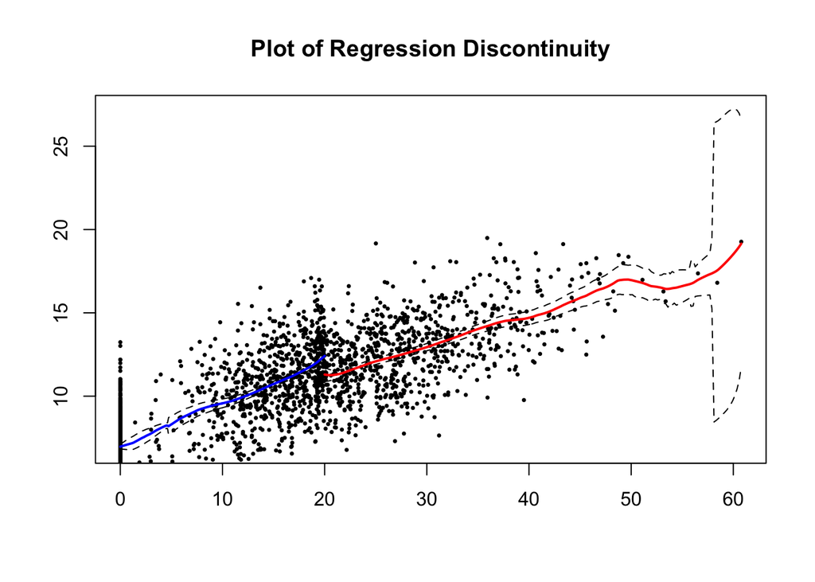

```r
RDplot(RDlinear_2, col = c("blue", "red"))
```

5. A colleague now points out to you that some women may have incentives in these settings to misreport their actual income. Plot a histogram of reported income and look for anything that might support or refute such a claim. What assumption is called into question if women are truly misreporting in this manner? [2 pts]

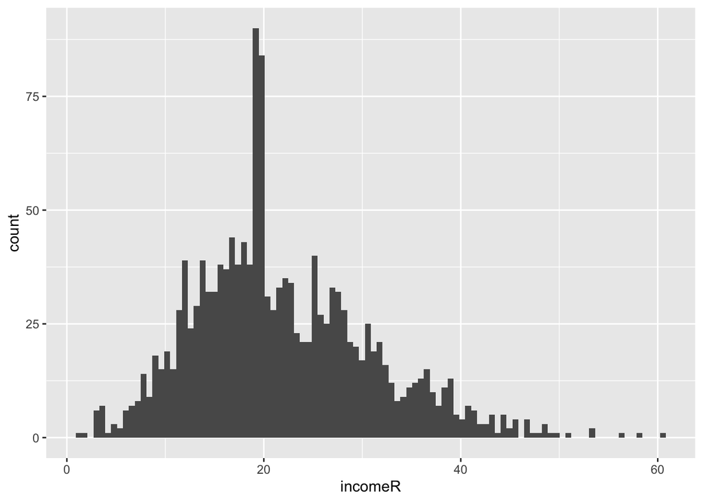

```r
#plotting a histgram without the income-values that equal zero
hospitals_data %>%
  filter(incomeR > 0) %>%
  ggplot(aes(x = incomeR)) +
  geom_histogram(bins = 100)
```

As we can see in the histogram, there is an very unusual distribution of income around the threshold of 20,000. Apperently, a lot of women have an income of just about under 20,000 and way less women over 20,000. This is very unlikley unless there are other factors either influencing the actual income (e.g. taxes) or many women are falsly reporting their income to be eligible for the program. Therefore we can conclude, that the distribution of incomes (the bunching just before 20,000) supports the claim of the colleague, that women have incentives to misreport their actual income.

The women’s behavior is invalidating the continuity assumption (by strategically choosing their values of Xi to fall on the beneficial side of the threshold). Continuity assumption: Continuity of average potential outcomes E(Yi(d)∣Xi = x) is continuous in x around Xi = c for d = 0, 1.

6. Another colleague points out to you that several other government programs (including food stamps etc.) have the same income threshold for eligibility. How might this knowledge impact your interpretation of your results? [2 pt]

Food stamps may also drive the result obtained. Due to these other programs, we cannot attribute LATE to the program under consideration. We have to be careful with our interpretation of the result because we could be facing omitted variable bias and potentially also a violation of the exclusion restrictions assumptions. The cutoff is connected to the outcome also trough the participation in other programs, therefore we should control for those ommited varaibles (i.e. participation in other programs) to get an unbiased estimte of the effect of our program on health.